# Capstone Project - Milestone Report

# Instructions

The goal of this project is just to display that you’ve gotten used to working with the data and that you are on track to create your prediction algorithm. Please submit a report on R Pubs (http://rpubs.com/) that explains your exploratory analysis and your goals for the eventual app and algorithm. This document should be concise and explain only the major features of the data you have identified and briefly summarize your plans for creating the prediction algorithm and Shiny app in a way that would be understandable to a non-data scientist manager. You should make use of tables and plots to illustrate important summaries of the data set.

The motivation for this project is to:

1. Demonstrate that you’ve downloaded the data and have successfully loaded it in.
2. Create a basic report of summary statistics about the data sets.
3. Report any interesting findings that you amassed so far.
4. Get feedback on your plans for creating a prediction algorithm and Shiny app.

# Review Criteria

Does the link lead to an HTML page describing the exploratory analysis of the training data set? Has the data scientist done basic summaries of the three files? Word counts, line counts and basic data tables? Has the data scientist made basic plots, such as histograms to illustrate features of the data? Was the report written in a brief, concise style, in a way that a non-data scientist manager could appreciate?

### Load data into R

```r
library(tm)
library(ggplot2)
library(wordcloud)
```

```r
path_us_blog <- file.path("/users/petramala/downloads/final/en_US/en_US.blogs.txt")
path_us_news <- file.path("/users/petramala/downloads/final/en_US//en_US.news.txt")
path_us_twitter <- file.path("/users/petramala/downloads/final/en_US//en_US.twitter.txt")
```

```r
#Read in text files
data_us_blog <- readLines(path_us_blog, encoding="UTF-8", skipNul=TRUE)
data_us_twitter <- readLines(path_us_twitter, encoding="UTF-8", skipNul=TRUE)
data_us_news <- readLines(path_us_news, encoding="UTF-8", skipNul=TRUE)
```

```r
head(data_us_blog,10)
```

```
##  [1] "In the years thereafter, most of the Oil fields and platforms were named after pagan “gods”."
##  [2] "We love you Mr. Brown."
##  [3] "Chad has been awesome with the kids and holding down the fort while I work later than usual! The kids have been busy together playing Skylander on the XBox together, after Kyan cashed in his $$$ from his piggy bank. He wanted that game so bad and used his gift card from his birthday he has …
##  [4] "so anyways, i am going to share some home decor inspiration that i have been storing in my folder on the puter. i have all these amazing images stored away ready to come to life when we get our home."
##  [5] "With graduation season right around the corner, Nancy has whipped up a fun set to help you out with not only your graduation cards and gifts, but any occasion that brings on a change in one's life. I stamped the images in Memento Tuxedo Black and cut them out with circle Nestabilities. I em…
##  [6] "If you have an alternative argument, let's hear it! :)"
##  [7] "If I were a bear,"
##  [8] "Other friends have similar stories, of how they were treated brusquely by Laurelwood staff, and as often as not, the same names keep coming up. About a half-dozen friends of mine refuse to step foot in there ever again because of it. How many others they’re telling - and keeping away - one …
##  [9] "Although our beloved Cantab can’t claim the international recognition afforded the Station Inn, otherwise these two joints feel like twins separated by nothing more than distance. They share a complete lack of pretense that can’t be imitated or approximated. Their very ordinariness makes th…
## [10] "Peter Schiff: Hard to tell. It will look pretty bad for most Americans when prices will go way up and they can’t afford to buy stuff. It could also get very bad as far as loss of individual liberty. A lot of people will blame it on capitalism, on freedom, and they will claim we need more go…
```

```r
head(data_us_twitter,10)
```

```
##  [1] "How are you? Btw thanks for the RT. You gonna be in DC anytime soon? Love to see you. Been way, way too long."
##  [2] "When you meet someone special... you'll know. Your heart will beat more rapidly and you'll smile for no reason."
##  [3] "they've decided its more fun if I don't."
##  [4] "So Tired D; Played Lazer Tag & Ran A LOT D; Ughh Going To Sleep Like In 5 Minutes ;)"
##  [5] "Words from a complete stranger! Made my birthday even better :)"
##  [6] "First Cubs game ever! Wrigley field is gorgeous. This is perfect. Go Cubs Go!"
##  [7] "i no! i get another day off from skool due to the wonderful snow (: and THIS wakes me up...damn thing"
##  [8] "I'm coo... Jus at work hella tired r u ever in cali"
##  [9] "The new sundrop commercial ...hehe love at first sight"
## [10] "we need to reconnect THIS WEEK"
```

```r
head(data_us_news,10)
```

```
##  [1] "He wasn't home alone, apparently."
##  [2] "The St. Louis plant had to close. It would die of old age. Workers had been making cars there since the onset of mass automotive production in the 1920s."
##  [3] "WSU's plans quickly became a hot topic on local online sites. Though most people applauded plans for the new biomedical center, many deplored the potential loss of the building."
##  [4] "The Alaimo Group of Mount Holly was up for a contract last fall to evaluate and suggest improvements to Trenton Water Works. But campaign finance records released this week show the two employees donated a total of $4,500 to the political action committee (PAC) Partners for Progress in earl…
##  [5] "And when it's often difficult to predict a law's impact, legislators should think twice before carrying any bill. Is it absolutely necessary? Is it an issue serious enough to merit their attention? Will it definitely not make the situation worse?"
##  [6] "There was a certain amount of scoffing going around a few years ago when the NFL decided to move the draft from the weekend to prime time -- eventually splitting off the first round to a separate day."
##  [7] "14915 Charlevoix, Detroit"
##  [8] "\"It’s just another in a long line of failed attempts to subsidize Atlantic City,\" said Americans for Prosperity New Jersey Director Steve Lonegan, a conservative who lost to Christie in the 2009 GOP primary. \"The Revel Casino hit the jackpot here at government expense.\""
##  [9] "But time and again in the report, Sullivan called on CPS to correct problems to improve employee accountability, saying, for example, that measures to keep employees from submitting fraudulent invoices or to block employees from accessing inappropriate websites were not in place."
## [10] "\u0093I was just trying to hit it hard someplace,\u0094 said Rizzo, who hit the pitch to the opposite field in left-center. \u0093I\u0092m just up there trying to make good contact.\u0094"
```

### Information about datasets

#### Size of the files

```r
format(object.size(data_us_blog), units = "auto")
```

```
## [1] "255.4 Mb"
```

```r
format(object.size(data_us_twitter), units = "auto")
```

```
## [1] "319 Mb"
```

```r
format(object.size(data_us_news), units = "auto")
```

```
## [1] "257.3 Mb"
```

#### Number of lines

```r
data_us_blog_lines <- length(data_us_blog)
data_us_twitter_lines <- length(data_us_twitter)
data_us_news_lines <-length(data_us_news)

data_us_blog_lines
```

```
## [1] 899288
```

```r
data_us_twitter_lines
```

```
## [1] 2360148
```

```r
data_us_news_lines
```

```
## [1] 1010242
```

```r
which.max(lapply(data_us_blog, nchar))
```

```
## [1] 483415
```

```r
which.max(lapply(data_us_twitter, nchar))
```

```
## [1] 26
```

```r
which.max(lapply(data_us_news, nchar))
```

```
## [1] 123628
```

#### Number of words

```r
sum(sapply(strsplit(data_us_blog, "\\s+"), length))
```

```
## [1] 37334149
```

```r
sum(sapply(strsplit(data_us_twitter, "\\s+"), length))
```

```
## [1] 30373605
```

```r
sum(sapply(strsplit(data_us_news, "\\s+"), length))
```

```
## [1] 34372814
```

### Pre-processing Data

#### Corpus

Join datasets and create the corpus

```r
# consolidating files
# getting sample of each file


sample_data_us_blog <- sample(data_us_blog, size = 1000)
sample_data_us_twitter <- sample(data_us_twitter, size = 1000)
sample_data_us_news <- sample(data_us_news, size = 1000)

JoinedData <- c(sample_data_us_blog,sample_data_us_twitter, sample_data_us_news)

MakeCorpus<- VCorpus(VectorSource(JoinedData))
```

Remove stopwords, white space, punctuation etc.

```r
toSpace  <- content_transformer(function(x, pattern) gsub(pattern, " ", x))

MakeCorpus <- tm_map(MakeCorpus, toSpace,"/|@|//|$|:|:)|*|&|!|?|_|-|#|")
MakeCorpus <- tm_map(MakeCorpus, removeNumbers)
MakeCorpus <- tm_map(MakeCorpus, content_transformer(tolower))
MakeCorpus <- tm_map(MakeCorpus, removeWords, stopwords("english"))
MakeCorpus <- tm_map(MakeCorpus, removePunctuation)
MakeCorpus <- tm_map(MakeCorpus, stripWhitespace)
```

Create the DTM

```r
 # monogram
dtm1 <- TermDocumentMatrix(MakeCorpus)

# bigram

# library Rweka is not working on my machine due to java error. This is an alternative approach to n-grams
bigram <- function(x) {
      unlist(lapply(ngrams(words(x), 2), paste, collapse = " "), use.names = FALSE)
}

dtm2 <- TermDocumentMatrix(MakeCorpus, control=list(tokenize = bigram))


# trigram

trigram <- function(x) {
      unlist(lapply(ngrams(words(x), 3), paste, collapse = " "), use.names = FALSE)
}

dtm3 <- TermDocumentMatrix(MakeCorpus, control=list(tokenize = trigram))
```

### Data Exploration

#### Monograms Frequency

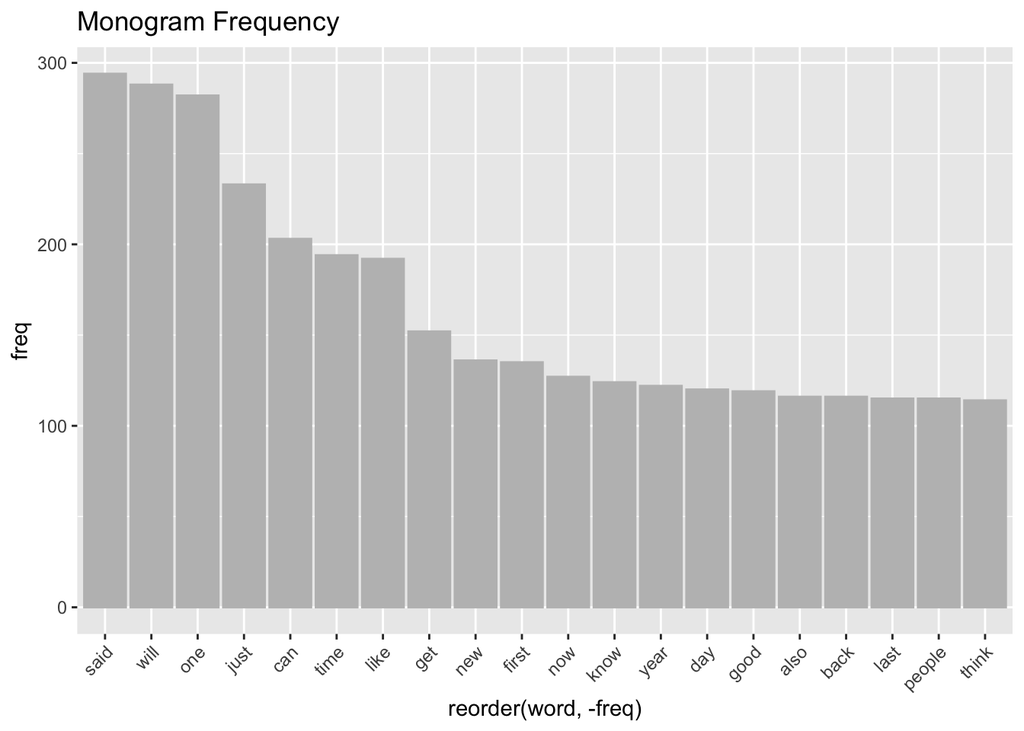

```r
mono_freq <- rowSums(as.matrix(dtm1))
mono_freq <- sort(mono_freq, decreasing = TRUE)
dfmono_freq <- data.frame(word = names(mono_freq), freq=mono_freq)
ggplot(dfmono_freq[1:20, ], aes(x = reorder(word, -freq), freq)) +
  geom_bar(stat="identity", fill="grey", colour="grey") +
  theme(axis.text.x=element_text(angle=45, hjust=1)) + ggtitle("Monogram Frequency")
```

#### 2-Gram Frequency

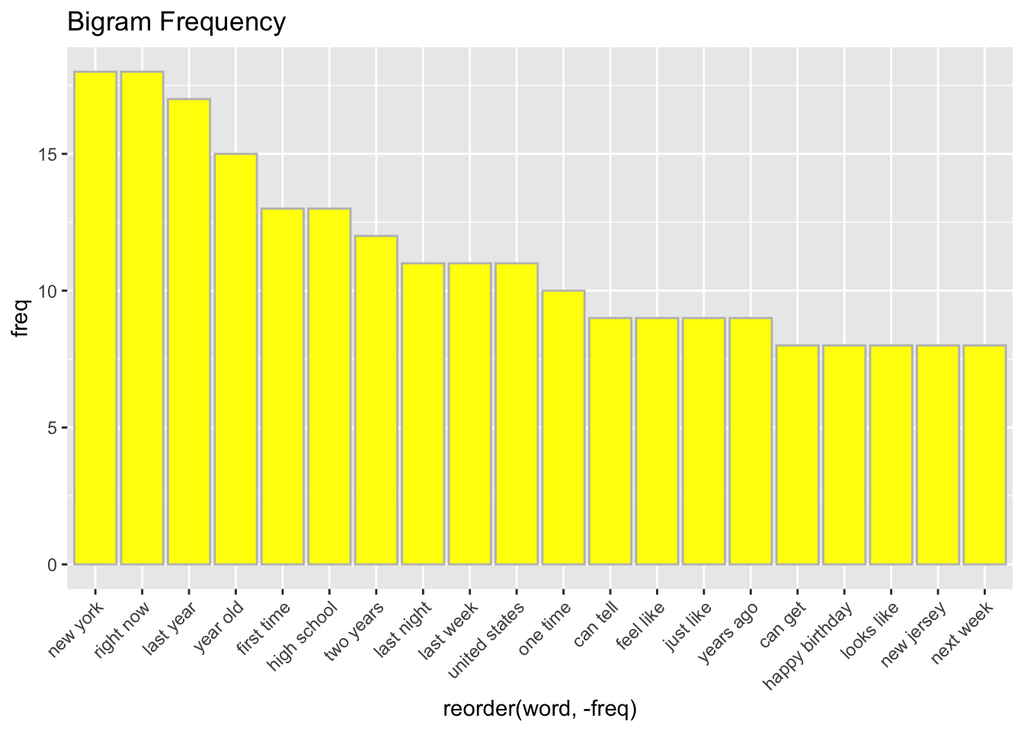

```r
bi_freq <- rowSums(as.matrix(dtm2))
bi_freq <- sort(bi_freq, decreasing = TRUE)
dfbi_freq <- data.frame(word = names(bi_freq), freq=bi_freq)
ggplot(dfbi_freq[1:20, ], aes(x = reorder(word, -freq), freq)) +
  geom_bar(stat="identity", fill="yellow", colour="grey") +
  theme(axis.text.x=element_text(angle=45, hjust=1)) + ggtitle("Bigram Frequency")
```

#### 3-Gram Frequency

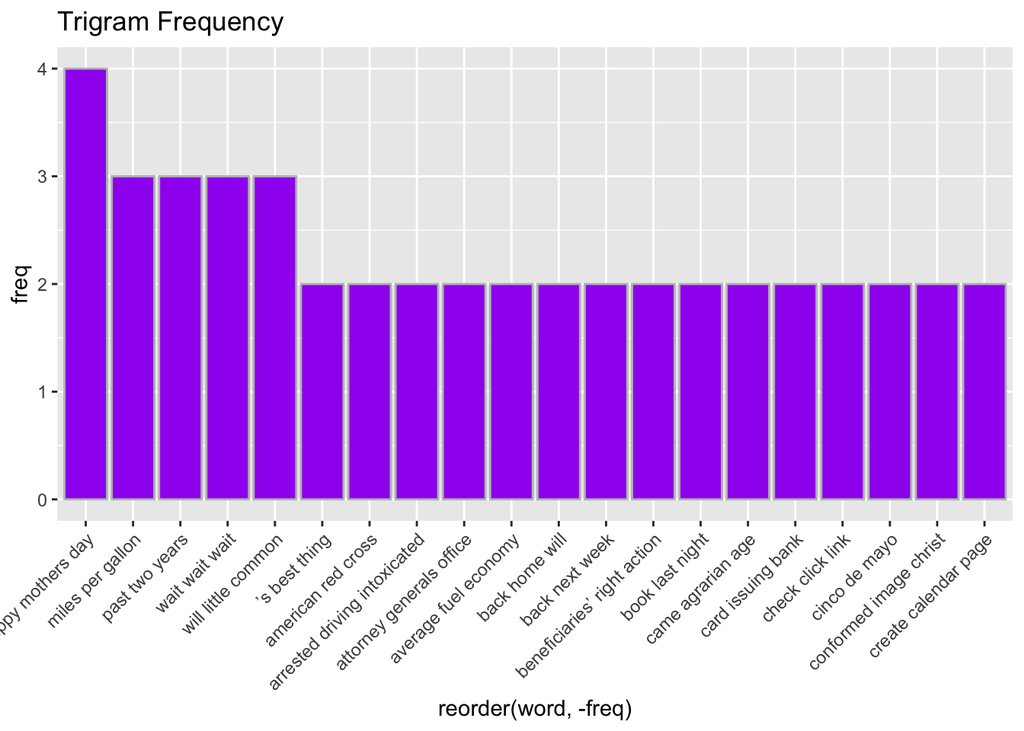

```r
tri_freq <- rowSums(as.matrix(dtm3))
tri_freq <- sort(tri_freq, decreasing = TRUE)
dftri_freq <- data.frame(word = names(tri_freq), freq=tri_freq)
ggplot(dftri_freq[1:20, ], aes(x = reorder(word, -freq), freq)) +
  geom_bar(stat="identity", fill="purple", colour="grey") +
  theme(axis.text.x=element_text(angle=45, hjust=1)) + ggtitle("Trigram Frequency")
```

#### WordCloud

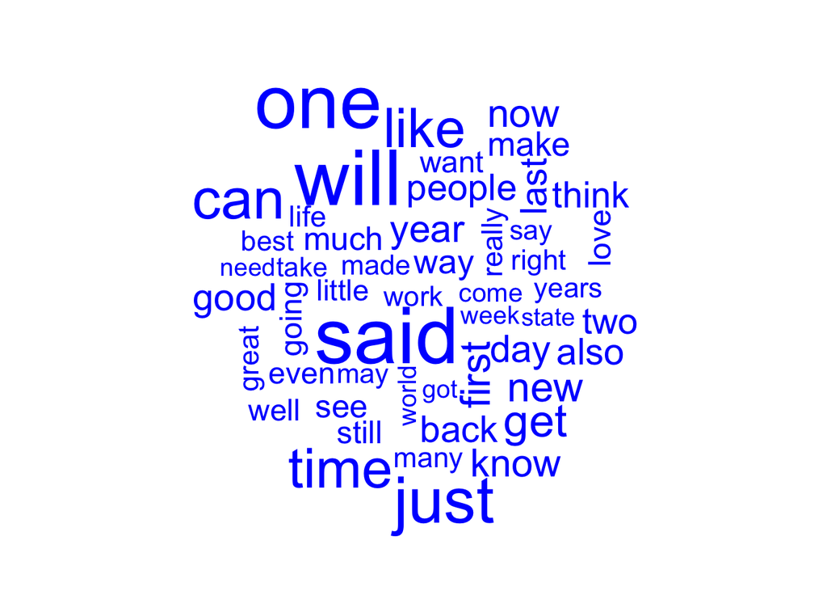

```r
# Vector of terms
terms_vec <- names(mono_freq)

wordcloud(terms_vec, mono_freq, max.words = 50, colors = "blue")
```

### Interesting findings

I came across a java issue with loading Rweka library which I was’t able to fix in a reasonable time. Instead I found alternative solution without using this library which you can find in Create the DTM part.

It’s also useful to see how similarities in text decrease with n-grams.

If I would want to explore this even further, it would be useful to look at it not just for the joined subset but each file separately to see if there isn’t particular issue in one them.